# Summary Léon

Autore/Autrice

Ottavia & Livio

# Léon

Tutta la selezione è basata sulla TIF media, questo implica che anche la TIF target sia la TIF media ottenuta da tutti gli item nell’item bank $B$.

A differenza di Frank che va per la sua strada senza considerare il fatto che le persone possano stancarsi, Léon aggiunge una sorta di penalità di stanchezza per ogni item aggiunto alla forma breve. Va considerato di staccare il vettore di stanchezze dai parametri degli item. Comunque, si ha un vettore di stanchezze, la cui lunghezza è uguale a $||B||$. Ad ogni iterazione, Léon calcola le information functions degli item, considerando i parametri a disposizione, ovvero $b_i$ (difficoltà), $a_i$ discriminatività, $c_i$ ($c_i = c = 0$) e la stanchezza, rappresentata dall’asintoto superiore $d$. L’asintonto viene spostato verso il basso ad ogni item aggiunto alla forma breve, andando a prendere il valore corrispondente di stanchezza dal vettore di stanchezze e assegnandolo come $d_i$ per tutti gli item a quella specifica iterazione.

Siccome poi Léon funziona come Frank, ovvero:

“garantisce” che venga scelto l’item migliore, al netto dell’effetto della stanchezza.

I risultati presentati in questo file sono ottenuti dal file `simulazione-theta-estimate-50item.R`

Qui c’è il codice di Léon, più o meno ottimizzato (quando lo modifichi, sii gentile e non farmi soffrire più del necessario):

**Codice**

```r
leon = function(parameters, target, speed = 0.01) {
  theta = target$theta
  all_iifs = item_info(parameters, theta)
  original_parameters = parameters
  start_e = parameters$e
  token = TRUE
  mod_e = 1
  j = 0
  while (token == TRUE) {
    j = j +1
    # qui potrei fare che itero per tutte le colonne che non sono NA del mio dataframe di item
    # creo gli indici degli item nell'insieme A (gli available items)
    if (all(which(is.na(parameters[, 1])) == FALSE) ) {
      item_indexes = 1:nrow(parameters)
      iif_stf = numeric(length(target$theta))
    } else {
      item_indexes = which(!is.na(parameters[,1]))
    }
    # adesso il ciclo for itera negli item indexes e calcola la PIF
    difference = rep(NA, nrow(parameters))
    for (i in item_indexes) {
      if (length(item_indexes) == nrow(parameters)) {
        pif = data.frame(all_iifs[,i])
      } else {
        # qui devo mdoficare all_iifs nel senso che le devo ricalcolare
        # però considerando la stanchezza
        # so dire esattamente
        # CAMBIA QUI METTENDO CHE PESCA LA E DEGLI ITEM ORIGIANLI IN ABSE ALLA LORO POSIZIONE DI SOMMNISTRAZIONE
        # PER CUI ALL'I-ESIMA ITERAZIONE PRENDE LA STANCHEZZA DELL'ITEM SOMMINISTRATO PER I-ESIMO
        # original_parameters$e = exp(-speed*(ncol(iif_stf)+1))
        original_parameters$e = start_e[j]
        # qui ora si può ottimizzare
        all_iifs = item_info(original_parameters[i,], theta)
        pif = data.frame(cbind(iif_stf, all_iifs))
        pif = data.frame(rowMeans(pif))
      }
      difference[i] = mean(abs(target$mean_tif - pif)[,1])
      # qui scelgo un item temporaneo che è quello con la distanza minima
    }
    mod_e = c(mod_e, unique(original_parameters$e))
    # qui trovo l'item che minimizza e lo metto in d
    d_index = which(difference == min(difference, na.rm = T))
    # adesso devo testare il criterio di uscita dove prendo la pif con l'ìitem che
    # minimizza, faccio la differenza dalla target e guardo come si comporta
    # rispetto alla distanza dalla target dello step precedente
    # qui ho riscoruito la provisional tif
    pif = data.frame(iif_stf, item_info(original_parameters[d_index,], theta))
    if (all(pif[,1] == 0) ) {
      distance_target_tif = mean(abs(target$mean_tif - iif_stf))
      pif = pif[,-1]
      iif_stf = data.frame(pif)
      colnames(iif_stf) = paste("item", d_index, sep = "_")
    } else {
      distance_target_tif = mean(abs(target$mean_tif - rowMeans(iif_stf)))
      iif_stf = pif
      colnames(iif_stf)[ncol(iif_stf)] = paste("item", d_index, sep = "_")
    }
    # guardo le differenze
    # effettivamente non c'è bisogno di mettere su tutto questo cinema mi dovrebbe
    # bastare prendere la differenza già calcolata in difference
    # if (difference[d_index] < distance_target_tif & all(which(is.na(parameters[, 1])) == FALSE) ) {
    #   token = TRUE
    #   parameters[d_index, ] = NA
    # } else
    if (difference[d_index] >= distance_target_tif) {
      token = FALSE
      # sel_items = colnames(iif_stf)[-ncol(iif_stf)]
      # sel_items = sel_items[order(sel_items)]
      # sel_items = paste(sel_items, collapse = " ")
      temp_item = colnames(iif_stf)[-ncol(iif_stf)]
      temp_item = as.numeric(gsub("item_", "", temp_item))
      temp_item = temp_item[order(temp_item)]
      sel_items = paste("item", temp_item, sep = "_")
      sel_items = paste(sel_items, collapse = " ")
    } else {
      parameters[d_index, ] = NA
    }
  }
  iif_stf = data.frame(iif_stf[,-ncol(iif_stf)])
  results = list(q_leon = sel_items,
                 iif_stf = iif_stf,
                 mod_e = mod_e)

  return(results)
}
```

## Stima di $\theta$

Quello che abbiamo provato a fare è stato stimare il tratto latente $\theta$ considerando:

- Tutti gli item in $B$

> Sono stati simulati i dati con `rbinom()`, considerando come probabilità la probabilità ottenuta con l’equazione del 4PL. Essendo $d_i = d = 1$ e $c_i = c = 0$, gli asintoti stanno dove devono stare
- Tutti gli item in $B$ ma con la gente che si stanca

> Sono stati simulati i dati con `rbinom()`, considerando come probabilità la probabilità ottenuta con l’equazione del 4PL. $c_i = c =0$, ma $d_r= \exp(-\lambda r)$, dove $r$ è la posizione dell’item nella somministrazione e $\lambda$ è la velocità con cui si muove la stanchezza. Nelle risposte simualte è quindi considerato l’effetto della stanchezza
- La selezione di item fatta da Léon

> Come sopra ma ci sono meno item

Nel stimare il modello (2PL), si sono tenuti fissi i parametri degli item $b_i$ e $a_i$. Questo vuol dire che viene stimato **solo** il $\theta$ dei soggetti.

# Procedura

Ho ripetuto la stessa roba per 100 volte (che ho chiamato replications e ora te ne stai, ti prego).

**Elementi fissi**

Il $\theta$ vero

Il numero di item nell’item bank ($||B|| = 50$)

La funzione che determina la stanchezza

La lucky guess $c= 0$

**Elementi che cambiano**

Le difficoltà e le discriminatività degli item

$b \sim \mathcal{U}(-3,3)$, $a \sim \mathcal{U}(.9,2)$

La TIF target (ovvero la TIF media calcolata su tutti i 50 item **senza asintoti**)

Ad ogni replica ho fittato `lm(true_theta ~ theta_estimate)`, dove `theta_estimate`:

- stimato su tutti gli item senza stanchezza (`all`)
- stimato su tutti gli item con stanchezza (`All-Tired`)
- stimato sugli item di Léon (`Leon`)

Ho fatto anche altre cose.

# Risultati

**Stime coefficienti lm**

**Codice**

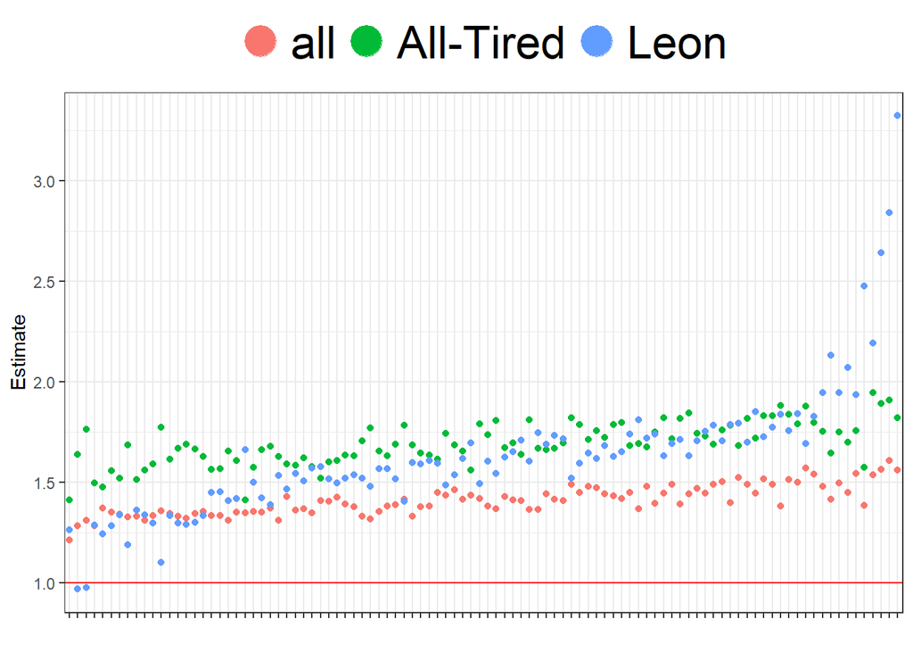

Figura 1: Beta degli LM rispetto all’1

````markdown
```{r}
#| fig-align: center
#| out-width: 100%
#| fig-cap: Beta degli LM rispetto all'1
#| label: fig-beta
# modelCoefLeon = data.frame(modelCoefLeon)
# modelCoefLeon$type = "Leon"
# modelCoefLeon$replica = modelCoef$replica
#
#
#
# modelCoefTired = data.frame(modelCoefTired)
# modelCoefTired$type = "All-Tired"
# modelCoefTired$replica = modelCoef$replica
#
#
allCoefs = rbind(modelCoef, modelCoefTired, modelCoefLeon)

ggplot(allCoefs[!grepl("Intercept", rownames(allCoefs)), ],
       aes( x = reorder(factor(replica), Estimate),
            y = Estimate, color = type)) + geom_point() +
  geom_hline(yintercept = 1, color = "red") +
  theme_bw()+ xlab("") +
  theme(legend.position = "top",
        legend.title = element_blank(),
        legend.text = element_text(size = 25),
        axis.text.x = element_blank()) +
  guides(color = guide_legend(override.aes = list(size = 8)))
```
````

**Con SE**

**Codice**

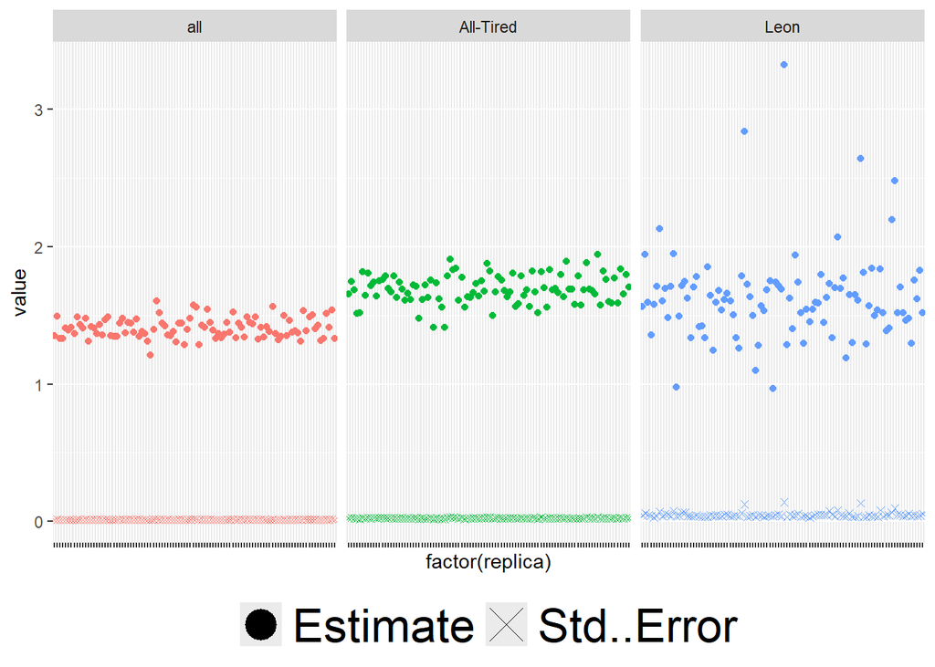

Figura 2: Beta degli LM rispetto all’1 con SE

````markdown
```{r}
#| fig-align: center
#| out-width: 100%
#| fig-cap: Beta degli LM rispetto all'1 con SE
#| label: fig-betaSE
temp = allCoefs[!grepl("Intercept", rownames(allCoefs)), ]

temp1 = pivot_longer(temp,
             cols = !c(type, replica))

ggplot(temp1,
       aes(x = factor(replica),
           y = value, shape = name, color = type)) + geom_point() +
  facet_grid(~type) + guides(color = "none") + scale_shape_manual(values = c(16, 4))+
theme(legend.position = "bottom",
      legend.title = element_blank(),
      legend.text = element_text(size = 25),
        axis.text.x = element_blank()) +
  guides(shape = guide_legend(override.aes = list(size = 8)))
```
````

## Rette di regressione

**Summary rette**

**Codice**

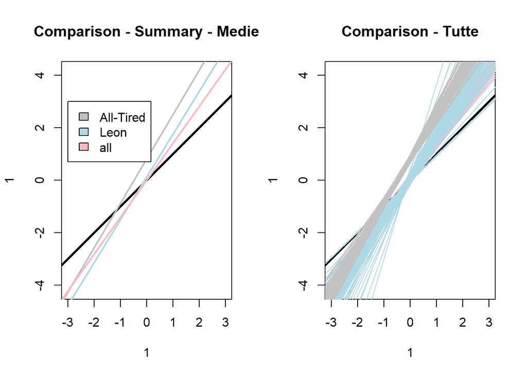

Figura 3: Summary rette di regressione

````markdown
```{r}
#| fig-align: center
#| out-width: 100%
#| fig-cap: Summary rette di regressione
#| label: fig-summaryRette
allCoefs$parametro = gsub("X.","", rownames(allCoefs))
allCoefs$parametro = gsub("[.0-9]", "", allCoefs$parametro)

saummaryPar = allCoefs %>%
  group_by(type, parametro) %>%
  summarise(mean = mean(Estimate), sd = sd(Estimate))




# voglio vedere i residui del modello
residualsLeon$theta = true_theta
resiLeon = pivot_longer(residualsLeon,
             cols = !theta)
par(mfrow = c(1, 2))
plot(1, 1, type = "n", asp = 1, xlim = c(-3,3), ylim =c(-3,3),
     main = "Comparison - Summary - Medie")
abline(0,1, lwd = 3)
colors = c("gray76", "lightblue", "lightpink")

for (i in 1:length(unique(saummaryPar$type))) {
  d = data.frame(saummaryPar[saummaryPar$type %in% unique(saummaryPar$type)[i], ])
  abline(d[1, "mean"], d[2, "mean"],
         col = colors[i], lwd = 2)
}
legend(x = -3, y = 3,
       legend = unique(saummaryPar$type),
       fill = c("gray76", "lightblue", "lightpink"))

plot(1, 1, type = "n", asp = 1, xlim = c(-3,3), ylim =c(-3,3),
     main = "Comparison - Tutte")
abline(0,1, lwd = 3)
for (i in 1:length(unique(modelCoef$replica))) {
  d = modelCoef[modelCoef$replica %in% unique(modelCoef$replica)[i],]
  abline(d[1, "Estimate"], d[2, "Estimate"],
         col = "lightpink")

}

for (i in 1:length(unique(modelCoefLeon$replica))) {
  d = modelCoefLeon[modelCoefLeon$replica %in% unique(modelCoefLeon$replica)[i],]
  abline(d[1, "Estimate"], d[2, "Estimate"],
         col = "lightblue")

}

for (i in 1:length(unique(modelCoefTired$replica))) {
  d = modelCoefTired[modelCoefTired$replica %in% unique(modelCoefTired$replica)[i],]
  abline(d[1, "Estimate"], d[2, "Estimate"],
         col = "gray76")

}
```
````

**Tutte le rette**

**Codice**

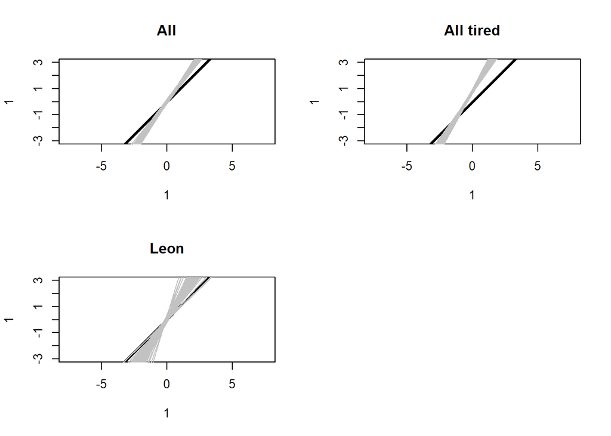

Figura 4: Dettaglio rette di regressione

````markdown
```{r}
#| fig-align: center
#| out-width: 100%
#| fig-cap: Dettaglio rette di regressione
#| label: fig-retteDettaglio

par(mfrow = c(2,2))
plot(1, 1, type = "n", asp = 1,xlim = c(-3,3), ylim =c(-3,3),
    main = "All")
abline(0,1, lwd = 3)
for (i in 1:length(unique(modelCoef$replica))) {
  d = modelCoef[modelCoef$replica %in% unique(modelCoef$replica)[i],]
  abline(d[1, "Estimate"], d[2, "Estimate"], col = "gray76")

}
plot(1, 1, type = "n", asp = 1, xlim = c(-3,3), ylim =c(-3,3),
     main = "All tired")
abline(0,1, lwd = 3)
for (i in 1:length(unique(modelCoefTired$replica))) {
  d = modelCoefTired[modelCoefTired$replica %in% unique(modelCoefTired$replica)[i],]
  abline(d[1, "Estimate"], d[2, "Estimate"], col = "gray76")

}
plot(1, 1, type = "n", asp = 1, xlim = c(-3,3), ylim =c(-3,3),
     main = "Leon")
abline(0,1, lwd = 3)
for (i in 1:length(unique(modelCoefLeon$replica))) {
  d = modelCoefLeon[modelCoefLeon$replica %in% unique(modelCoefLeon$replica)[i],]
  abline(d[1, "Estimate"], d[2, "Estimate"], col = "gray76")

}
```
````